# Stroop Effect: Test a Perceptual Phenomenon

## Background information

> In a Stroop task, participants are presented with a list of words, with each word displayed in a color of ink. The participant’s task is to say out loud the color of the ink in which the word is printed. The task has two conditions: a congruent words condition, and an incongruent words condition. In the congruent words condition, the words being displayed are color words whose names match the colors in which they are printed. In the incongruent words condition, the words displayed are color words whose names do not match the colors in which they are printed. In each case, we measure the time it takes to name the ink colors in equally-sized lists. Each participant will go through and record a time from each condition.

In this project, we will investigate a classic phenomenon from experimental psychology called the Stroop Effect. We will learn a little bit about the experiment, create a hypothesis regarding the outcome of the task, then go through the task. We will then look at some data collected from others who have performed the same task and will compute some statistics describing the results. Finally, we will interpret the results in terms of our hypotheses.

More information about [Stroop Effect](https://en.wikipedia.org/wiki/Stroop_effect)

### We will solve 5 questions for this project and we'll explore the dataset.

Let's load our data.

```python
import pandas
import numpy as np
import os
import matplotlib.pyplot as plt
%matplotlib inline
```

```python
dataFrame = pandas.read_csv(os.getcwd() + "/stroopdata.csv")
```

```python
dataFrame
```

|  | Congruent | Incongruent |
| --- | --- | --- |
| 0 | 12.079 | 19.278 |
| 1 | 16.791 | 18.741 |
| 2 | 9.564 | 21.214 |
| 3 | 8.630 | 15.687 |
| 4 | 14.669 | 22.803 |
| 5 | 12.238 | 20.878 |
| 6 | 14.692 | 24.572 |
| 7 | 8.987 | 17.394 |
| 8 | 9.401 | 20.762 |
| 9 | 14.480 | 26.282 |
| 10 | 22.328 | 24.524 |
| 11 | 15.298 | 18.644 |
| 12 | 15.073 | 17.510 |
| 13 | 16.929 | 20.330 |
| 14 | 18.200 | 35.255 |
| 15 | 12.130 | 22.158 |
| 16 | 18.495 | 25.139 |
| 17 | 10.639 | 20.429 |
| 18 | 11.344 | 17.425 |
| 19 | 12.369 | 34.288 |
| 20 | 12.944 | 23.894 |
| 21 | 14.233 | 17.960 |
| 22 | 19.710 | 22.058 |
| 23 | 16.004 | 21.157 |

# Question 1 :What is the independent variable? What is our Dependent Variable?

**Independent Variable:** Whether the font color and word name are the same or different. (Congruency)  
**Dependent Variable:** The amount of time it takes for the participant to indicate the color

# Question 2. What is an appropriate set of hypotheses for this task? What kind of statistical test do you expect to perform? Justify your choices.

**Null hypothesis (H0)**: The mean time for the population to name the ink colors is equal for the Congruent and Incongruent conditions (μC = μI);

**Alternative Hypothesis (H1)**: The mean time for the population to name the ink colors is different for the Congruent and Incongruent conditions (μC != μI);

We expect to perform a paired t-test, because:

- We assume the distributions are normal;
- The two samples are dependent;
- We do not know the population’s standard deviation;
- The samples size is below 30.

> Before moving on to our next question, let's explore some of the statistics of our dataframe variables

```python
dataFrame['Congruent'].describe()
```

```
count    24.000000
mean     14.051125
std       3.559358
min       8.630000
25%      11.895250
50%      14.356500
75%      16.200750
max      22.328000
Name: Congruent, dtype: float64
```

```python
dataFrame['Incongruent'].describe()
```

```
count    24.000000
mean     22.015917
std       4.797057
min      15.687000
25%      18.716750
50%      21.017500
75%      24.051500
max      35.255000
Name: Incongruent, dtype: float64
```

# Question 3. Report some descriptive statistics regarding this dataset. Include at least one measure of central tendency and at least one measure of variability.

Mean for **Congruent** - 14.05  
Mean for **Incongruent** - 22.01

Median for **Congruent** - 14.35  
Median for **Incongruent** - 21.01

**Mean difference**: -7.96  
**Standard deviation of the difference**: 4.86  
**Standard error of the mean difference**: .99  
Considering all data on the congruent and incongruent test groups have unique time no same time as the data is continuous there is no mode available on both test group. It is clearly visible from our observations that Incongruent Words were taking a longer time to be answered!

# Question 4. Provide one or two visualizations that show the distribution of the sample data. Write one or two sentences noting what you observe about the plot or plots.

```
<Container object of 10 artists>
```

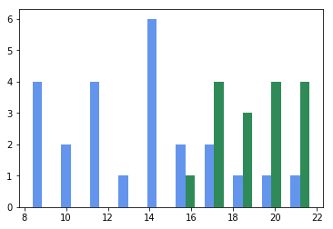

```python
df = dataFrame.copy()
fig, ax = plt.subplots()

a_heights, a_bins = np.histogram(df['Congruent'])
b_heights, b_bins = np.histogram(df['Incongruent'], bins=a_bins)

width = (a_bins[1] - a_bins[0])/3

ax.bar(a_bins[:-1], a_heights, width=width, facecolor='cornflowerblue')
ax.bar(b_bins[:-1]+width, b_heights, width=width, facecolor='seagreen')
```

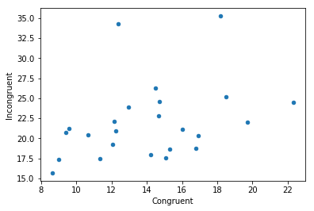

```python
dataFrame.plot.scatter(x='Congruent',y='Incongruent')
```

From our two plots above we can see clearly that majority of our observations those were congruent, took lesser time than our incongruent time.

In other words, the times on the incongruent sample are larger than on the congruent sample.

# Question 5 : What is your confidence level and your critical statistic value? Do you reject the null hypothesis or fail to reject it? Come to a conclusion in terms of the experiment task. Did the results match up with your expectations?